# 2018-09-11: first tidy tuesday: cat & dogs

## keep it simple:

### Objectives:

- work on data,
- practice,
- get better on your workflow,
- get better on your skills: import, tidy , understand( transform, visualize,model ) , communicate

https://rviews.rstudio.com/2017/06/08/what-is-the-tidyverse/

( migrating from ETL + analysis)

### workflow:

1st iteration:

- get the git project: https://github.com/rfordatascience/tidytuesday
- add a new folder where your works will be placed, ex: ‘jas1_weeks’
- inside it, add week folders inside with naming == data folder ; ex: ‘2018-09-11’
- add your rmd file for documenting your workflow, notes & stuff ; ex: ‘tidytuesday/jas1_weeks/2018-09-11/readme.rmd’
- get to the specific challenge tasks

#### Understand the business

- to understand what to do , you need to check the challenge objectives;
- read the article wich is being analized; more information on the data folder of the week: tidytuesday/data/2018-09-11

https://www.washingtonpost.com/news/wonk/wp/2014/07/28/where-cats-are-more-popular-than-dogs-in-the-u-s-and-all-over-the-world/

> some css tricks for reading: * F12 * display: none; * overflow: auto;
- make notes / scripts , document what you do.

#### Define your goal to do:

as 1st timer on tidy tuesday

- show the ordered tables
- make the map, hex-tiled
- add the cat/dog histogram from: https://data.world/datanerd/cat-vs-dog-popularity-in-u-s
- update the objective as i acommplish task; ( new ideas, or at least document " future work" )

#### Import: git clone + git merge from the original

- import the data from the current dataset (ctrl + alt + i: shortcut for insert R chunks in rmd in rstudio)
- peek raw data to have an intuition, ( always remember to check file size, because of larger datasets )
- refactor to make the proper read. (strings as factors= false)

```r
library(dplyr)
file_location <- '../../data/2018-09-11/cats_vs_dogs.csv'
raw_data <- read.csv(file_location,stringsAsFactors = FALSE)
glimpse( raw_data)
```

```
## Observations: 49
## Variables: 13
## $ X                      <int> 1, 2, 3, 4, 5, 6, 7, 8, 9, 10, 11, 12, ...
## $ state                  <chr> "Alabama", "Arizona", "Arkansas", "Cali...
## $ n_households           <int> 1828, 2515, 1148, 12974, 1986, 1337, 33...
## $ percent_pet_households <dbl> 59.5, 59.5, 62.4, 52.9, 61.3, 54.4, 56....
## $ n_pet_households       <int> 1088, 1497, 716, 6865, 1217, 728, 189, ...
## $ percent_dog_owners     <dbl> 44.1, 40.1, 47.9, 32.8, 42.5, 28.3, 33....
## $ n_dog_households       <int> 807, 1008, 550, 4260, 845, 379, 113, 38...
## $ avg_dogs_per_household <dbl> 1.7, 1.8, 2.0, 1.6, 1.6, 1.3, 1.4, 1.1,...
## $ dog_population         <int> 1410, 1798, 1097, 6687, 1349, 507, 163,...
## $ percent_cat_owners     <dbl> 27.4, 29.6, 30.6, 28.3, 32.3, 31.9, 33....
## $ n_cat_households       <int> 501, 743, 351, 3687, 642, 427, 113, 33,...
## $ avg_cats_per_household <dbl> 2.5, 1.9, 2.3, 1.9, 1.9, 1.9, 1.7, 1.9,...
## $ cat_population         <int> 1252, 1438, 810, 7118, 1191, 796, 187, ...
```

#### Tidy:

We can see, we got 49 observatitions, and 13 variables; and how are they structured.

```r
data <- raw_data %>% rename(id=X)
glimpse(data)
```

```
## Observations: 49
## Variables: 13
## $ id                     <int> 1, 2, 3, 4, 5, 6, 7, 8, 9, 10, 11, 12, ...
## $ state                  <chr> "Alabama", "Arizona", "Arkansas", "Cali...
## $ n_households           <int> 1828, 2515, 1148, 12974, 1986, 1337, 33...
## $ percent_pet_households <dbl> 59.5, 59.5, 62.4, 52.9, 61.3, 54.4, 56....
## $ n_pet_households       <int> 1088, 1497, 716, 6865, 1217, 728, 189, ...
## $ percent_dog_owners     <dbl> 44.1, 40.1, 47.9, 32.8, 42.5, 28.3, 33....
## $ n_dog_households       <int> 807, 1008, 550, 4260, 845, 379, 113, 38...
## $ avg_dogs_per_household <dbl> 1.7, 1.8, 2.0, 1.6, 1.6, 1.3, 1.4, 1.1,...
## $ dog_population         <int> 1410, 1798, 1097, 6687, 1349, 507, 163,...
## $ percent_cat_owners     <dbl> 27.4, 29.6, 30.6, 28.3, 32.3, 31.9, 33....
## $ n_cat_households       <int> 501, 743, 351, 3687, 642, 427, 113, 33,...
## $ avg_cats_per_household <dbl> 2.5, 1.9, 2.3, 1.9, 1.9, 1.9, 1.7, 1.9,...
## $ cat_population         <int> 1252, 1438, 810, 7118, 1191, 796, 187, ...
```

as 1st stransformation, X , its given the “id” name; as i think its more descriptive

we can see 2 variables do not have any sense to calculate stuff as they are categorical variables: state & id.

id for identification of observation and state, as a “category” / “grouping” ( http://www.abs.gov.au/websitedbs/a3121120.nsf/home/statistical+language+-+what+are+variables )

#### Understand:

##### Transform

lets take a look to some detail to all the variables; as im not quite happy with default “summary” just google tidiyverse summary; after digging little, and found skimr from ropensci: https://ropensci.org/blog/2017/07/11/skimr/

```r
library(skimr)#install.packages('skimr')
skim(data)
```

```
## Skim summary statistics
##  n obs: 49
##  n variables: 13
##
## -- Variable type:character --------------------------------------------------------------------------------------------
##  variable missing complete  n min max empty n_unique
##     state       0       49 49   4  20     0       49
##
## -- Variable type:integer ----------------------------------------------------------------------------------------------
##          variable missing complete  n    mean      sd  p0 p25  p50  p75
##    cat_population       0       49 49 1492.8  1459.86  63 514 1185 1844
##    dog_population       0       49 49 1414.16 1464.66  42 410 1097 1798
##                id       0       49 49   25      14.29   1  13   25   37
##  n_cat_households       0       49 49  728.06  717.29  33 247  501  876
##  n_dog_households       0       49 49  876.37  891.83  38 273  638 1069
##      n_households       0       49 49 2403.9  2514.05 221 765 1759 2632
##  n_pet_households       0       49 49 1342.59 1358.25  63 475  957 1611
##   p100     hist
##   7118 ▇▅▂▁▁▁▁▁
##   7163 ▇▅▂▁▁▁▁▁
##     49 ▇▇▇▇▇▇▇▇
##   3687 ▇▅▂▁▁▁▁▁
##   4260 ▇▆▂▁▁▁▁▁
##  12974 ▇▃▁▁▁▁▁▁
##   6865 ▇▆▂▁▁▁▁▁
##
## -- Variable type:numeric ----------------------------------------------------------------------------------------------
##                variable missing complete  n  mean   sd   p0  p25  p50  p75
##  avg_cats_per_household       0       49 49  2.04 0.19  1.7  1.9  2    2.2
##  avg_dogs_per_household       0       49 49  1.59 0.2   1.1  1.4  1.6  1.7
##      percent_cat_owners       0       49 49 31.64 5.68 11.6 29   31.3 33.8
##      percent_dog_owners       0       49 49 36.97 6.67 13.1 32.9 36.6 42.5
##  percent_pet_households       0       49 49 56.86 6.93 21.9 53.6 56.8 61.3
##  p100     hist
##   2.6 ▅▇▇▆▅▂▁▂
##   2.1 ▁▁▃▇▂▂▁▁
##  49.5 ▁▁▁▇▇▂▁▁
##  47.9 ▁▁▁▃▇▇▇▆
##  70.8 ▁▁▁▁▂▇▆▁
```

thats an oustanding summary; it tells you a lot , first of all , no missing values on any variable. and a mini histogram from em.

to take a look at distributions, always found helpfull the box plot: for that we need to transform the dataset from wide to long.

```r
library(tidyr)

long_data <- gather(data,key=variable,value=value,-state,-id)
glimpse(long_data)
```

```
## Observations: 539
## Variables: 4
## $ id       <int> 1, 2, 3, 4, 5, 6, 7, 8, 9, 10, 11, 12, 13, 14, 15, 16...
## $ state    <chr> "Alabama", "Arizona", "Arkansas", "California", "Colo...
## $ variable <chr> "n_households", "n_households", "n_households", "n_ho...
## $ value    <dbl> 1828, 2515, 1148, 12974, 1986, 1337, 334, 287, 7609, ...
```

##### Visuailze

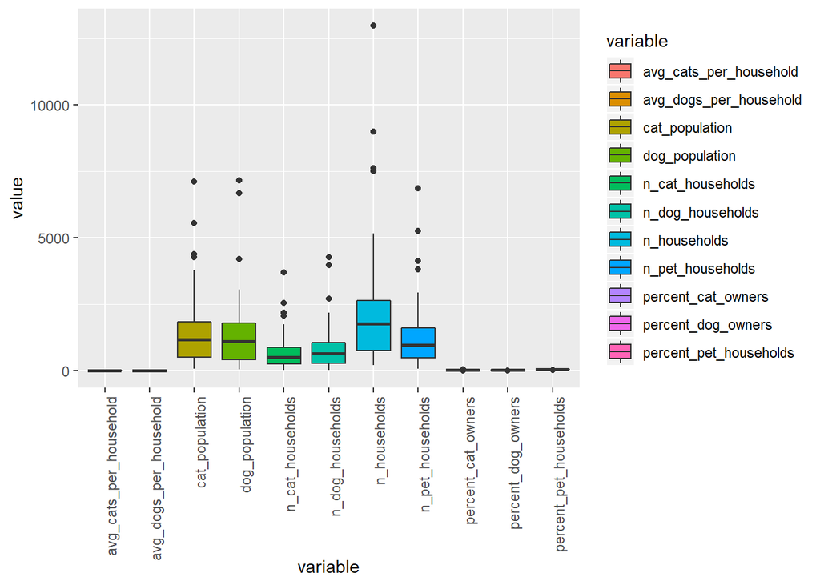

```r
library(ggplot2)
ggplot(long_data,aes(y=value,x=variable,fill=variable)) +
    geom_boxplot() +
    theme(axis.text.x = element_text(angle = 90, hjust = 1))
```

As seen some variables are not on same range of values: the avg & the percent.

##### Transform

```r
library(stringi)
library(stringr)
percent_data <- long_data%>% filter(str_detect(variable,"percent_") )
avg_data <- long_data%>% filter(str_detect(variable,"avg_") )
other_data <- long_data %>% filter( !str_detect(variable,"percent_")) %>% filter( !str_detect(variable,"avg_") )

# just to check the filter its ok
percent_data %>% group_by(variable) %>% tally() %>% select(variable)
```

```
## # A tibble: 3 x 1
##   variable
##   <chr>
## 1 percent_cat_owners
## 2 percent_dog_owners
## 3 percent_pet_households
```

```r
avg_data %>% group_by(variable) %>% tally()  %>% select(variable)
```

```
## # A tibble: 2 x 1
##   variable
##   <chr>
## 1 avg_cats_per_household
## 2 avg_dogs_per_household
```

```r
other_data %>% group_by(variable) %>% tally()  %>% select(variable)
```

```
## # A tibble: 6 x 1
##   variable
##   <chr>
## 1 cat_population
## 2 dog_population
## 3 n_cat_households
## 4 n_dog_households
## 5 n_households
## 6 n_pet_households
```

##### Visuailze

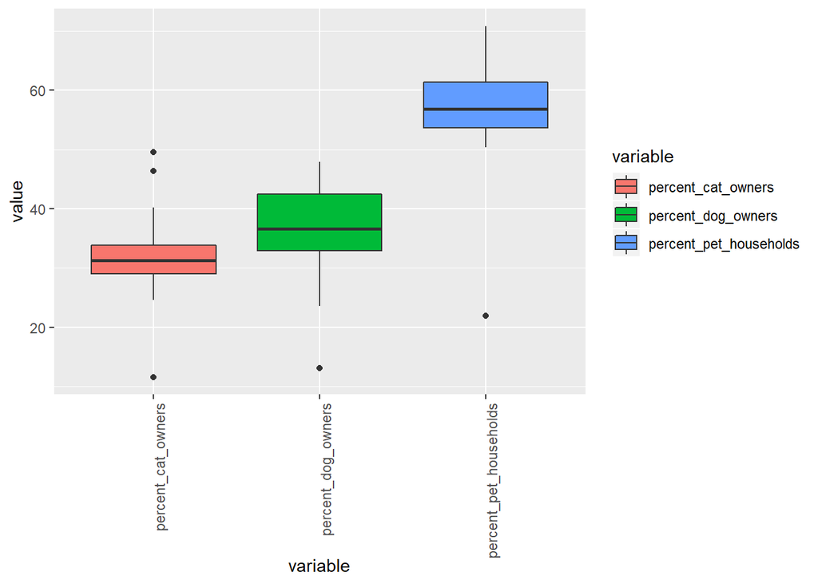

```r
ggplot(percent_data,aes(y=value,x=variable,fill=variable)) +
    geom_boxplot() +
    theme(axis.text.x = element_text(angle = 90, hjust = 1))
```

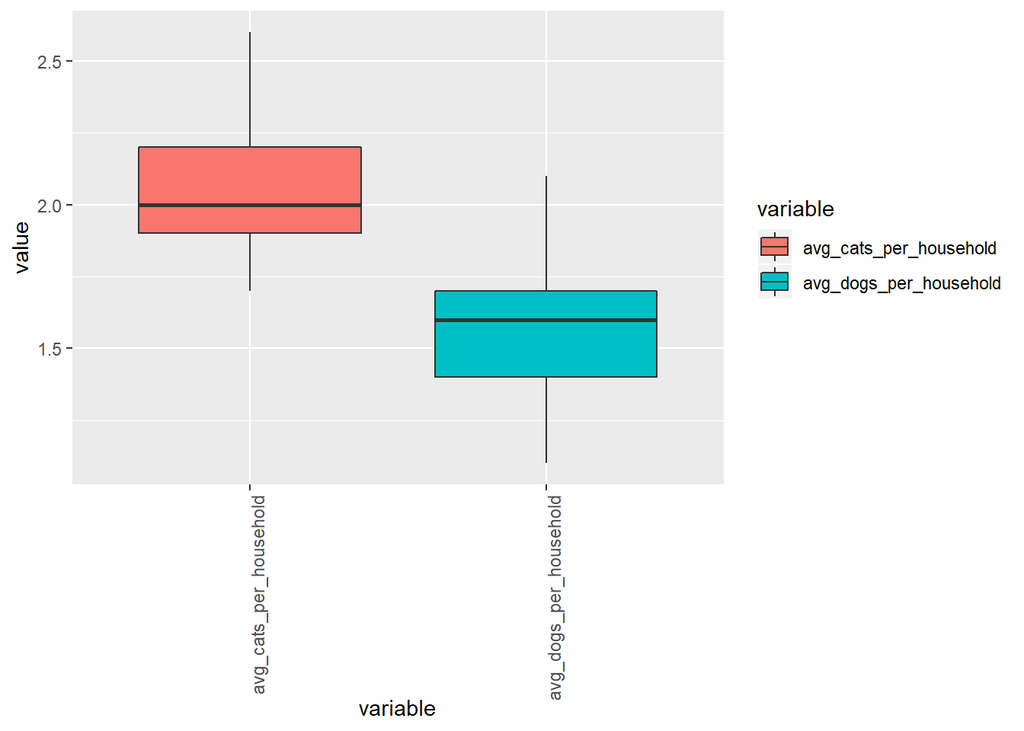

```r
ggplot(avg_data,aes(y=value,x=variable,fill=variable)) +
    geom_boxplot() +
    theme(axis.text.x = element_text(angle = 90, hjust = 1))
```

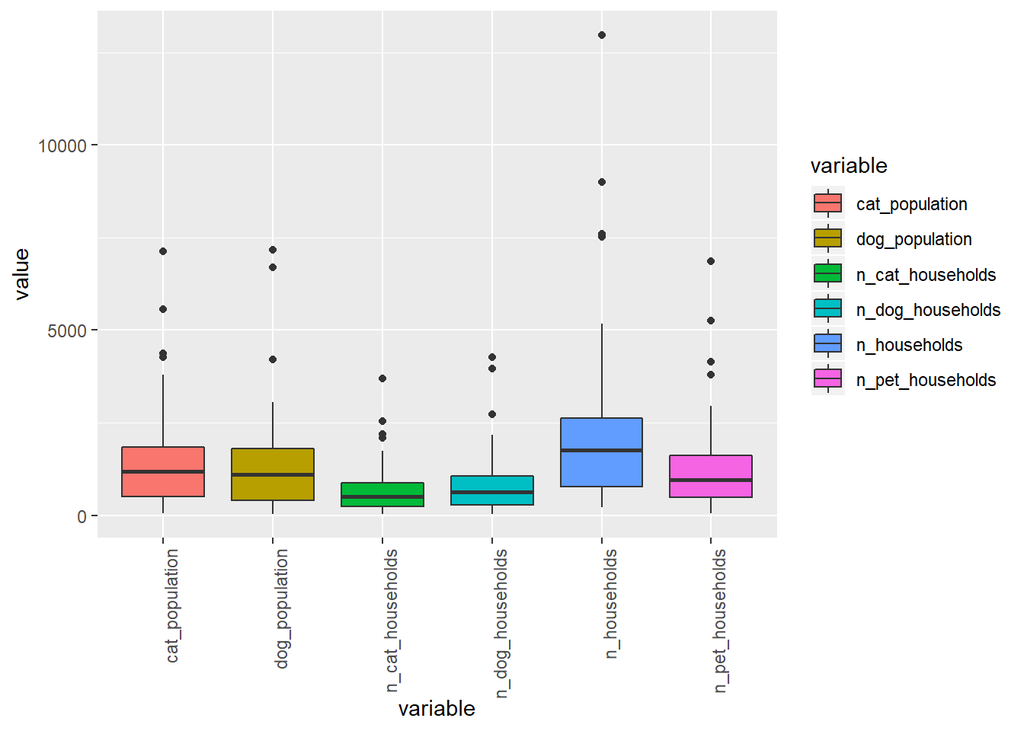

```r
ggplot(other_data,aes(y=value,x=variable,fill=variable)) +
    geom_boxplot() +
    theme(axis.text.x = element_text(angle = 90, hjust = 1))
```

watching the variables can be said a lot of stuff; and can build some rations on them.

as time assigned here, i’ll skip this analysis for later / future.

# Outputs:

For closing this first stage of tidytuesday , ill focus on the derivables

## show the ordered tables

before checking order, we need to see if data is consistent; not only numbers, but for the domain being analized.

in this case quantity of states, and no repeating; so we count the ocurrences, filter with N will be greather than 1

```r
data %>% count(state) %>% filter(n > 1)
```

```
## # A tibble: 0 x 2
## # ... with 2 variables: state <chr>, n <int>
```

luckily no repetitions.

Columns needed:

Rank State Cats Dogs Ratio, dogs to cats Ratio, cats to dogs

```r
process_data <- data %>%
    select(state,cat_population,dog_population) %>%
    mutate(ratio_dog_cat = dog_population/cat_population ) %>%
    mutate(ratio_cat_dog = cat_population/dog_population )
```

### Top 10 dog-loving states

```r
process_data %>% top_n(10,wt = ratio_dog_cat) %>% arrange(desc(ratio_dog_cat))
```

```
##          state cat_population dog_population ratio_dog_cat ratio_cat_dog
## 1     Arkansas            810           1097      1.354321     0.7383774
## 2   New Mexico            533            703      1.318949     0.7581792
## 3        Texas           5565           7163      1.287152     0.7769091
## 4     Oklahoma           1041           1327      1.274736     0.7844763
## 5    Louisiana            877           1115      1.271380     0.7865471
## 6  Mississippi            668            846      1.266467     0.7895981
## 7      Arizona           1438           1798      1.250348     0.7997775
## 8    Tennessee           1749           2157      1.233276     0.8108484
## 9     Missouri           1653           1978      1.196612     0.8356926
## 10     Georgia           2162           2479      1.146623     0.8721259
```

### Top 10 cat-loving states

```r
process_data %>% top_n(10,wt = ratio_cat_dog) %>% arrange(desc(ratio_cat_dog))
```

```
##                   state cat_population dog_population ratio_dog_cat
## 1         Massachusetts           1593            850     0.5335844
## 2              Maryland           1677            915     0.5456172
## 3                 Maine            498            300     0.6024096
## 4               Vermont            234            142     0.6068376
## 5           Connecticut            796            507     0.6369347
## 6  District of Columbia             63             42     0.6666667
## 7         New Hampshire            309            212     0.6860841
## 8          Pennsylvania           3544           2485     0.7011851
## 9              New York           4261           3054     0.7167332
## 10                 Ohio           3786           2730     0.7210777
##    ratio_cat_dog
## 1       1.874118
## 2       1.832787
## 3       1.660000
## 4       1.647887
## 5       1.570020
## 6       1.500000
## 7       1.457547
## 8       1.426157
## 9       1.395219
## 10      1.386813
```

## Cat/dog histogram from:

https://data.world/datanerd/cat-vs-dog-popularity-in-u-s

needed the percent difference: dogs - cats

usefull links:

- http://www.sthda.com/english/wiki/ggplot2-title-main-axis-and-legend-titles
- http://www.sthda.com/english/wiki/ggplot2-essentials
- http://www.sthda.com/english/wiki/ggplot2-axis-ticks-a-guide-to-customize-tick-marks-and-labels
- http://www.sthda.com/english/wiki/ggplot2-legend-easy-steps-to-change-the-position-and-the-appearance-of-a-graph-legend-in-r-software

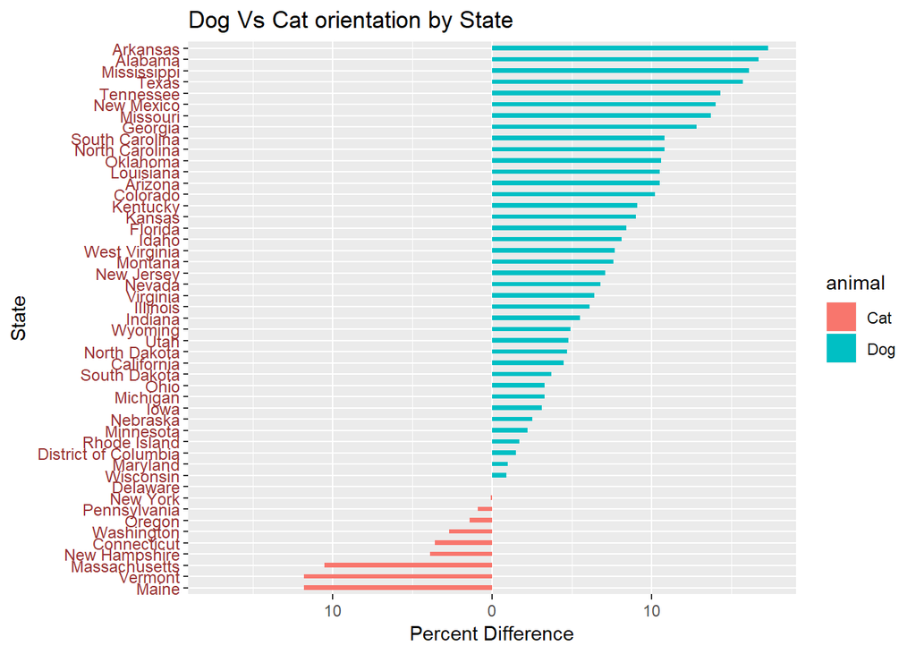

```r
process_data_hist_all <- data %>%
    mutate(percent_diff = percent_dog_owners-percent_cat_owners) %>%
    mutate(animal=if_else(percent_diff >0,"Dog","Cat"))

process_data_hist <- process_data_hist_all  %>%
    select(state,percent_diff,animal) %>%
    arrange(desc(percent_diff))

# glimpse(process_data_hist)

# process_data_hist %>% arrange(desc(percent_diff))

# ggplot(process_data_hist,aes(x=state))+geom_bar(stat = id)

ggplot(data = process_data_hist,
       mapping = aes(x = reorder(state, percent_diff), fill = animal,
                     y = ifelse(animal == "Cat", percent_diff, percent_diff))) +
  geom_bar(stat = "identity", # for the value
           width=0.4 ) +#, # for thiner bars
          # position = position_dodge(width=0.5)) +
  scale_y_continuous(labels = abs, limits = max(process_data_hist$percent_diff) * c(-1,1)) +
  labs(y = "Percent Difference") +
  coord_flip() +
    ggtitle("Dog Vs Cat orientation by State") +
    ylab("Percent Difference") +
    xlab("State") +
    theme(axis.text.y = element_text( color="#993333", size=9,margin = margin(2, 2, 2, 2)))
```

```r
    # couldnt make the label axis space ok.
```

## Map, hex-tiled

utils:

https://www.r-graph-gallery.com/328-hexbin-map-of-the-usa/

https://stackoverflow.com/questions/37912418/how-does-geom-map-map-id-function-work

http://ryanhafen.com/blog/geofacet

```r
library(geojsonio) #install.packages("geojsonio")
```

```r
spdf <- geojson_read("us_states_hexgrid.geojson",  what = "sp")

# I need to 'fortify' the data to be able to show it with ggplot2 (we need a data frame format)
library(broom)
spdf@data = spdf@data %>% mutate(google_name = gsub(" \\(United States\\)", "", google_name))
spdf_fortified <- tidy(spdf, region = "google_name")
```

[output not shown]

[output cut: 97 more lines]

[output not shown]

```r
library(rgeos) #install.packages("rgeos")
```

```r
centers <- cbind.data.frame(data.frame(gCentroid(spdf, byid=TRUE), id=spdf@data$iso3166_2))

library(mapproj) #install.packages("mapproj")
# Now I can plot this shape easily as described before:
# ggplot() +
#   geom_polygon(data = spdf_fortified, aes( x = long, y = lat, group = group), fill="skyblue", color="white") +
#   geom_text(data=centers, aes(x=x, y=y, label=id)) +
#   theme_void() +
#   coord_map()


# percent_data_long <- process_data_hist %>% spread(key = variable,value=value)
# glimpse(percent_data_long)

# Merge geospatial and numerical information
spdf_fortified_cat_dogs  <-  spdf_fortified %>%
    left_join(. , process_data_hist, by=c("id"="state"))

# glimpse(spdf_fortified_cat_dogs)

spdf_fortified_cat_dogs_percent <- spdf_fortified_cat_dogs
glimpse(spdf_fortified_cat_dogs)
```

```
## Observations: 357
## Variables: 9
## $ long         <dbl> -94.40873, -91.68585, -91.68585, -94.40873, -97.1...
## $ lat          <dbl> 35.79821, 34.51297, 31.88246, 30.53798, 31.88246,...
## $ order        <int> 1, 2, 3, 4, 5, 6, 7, 8, 9, 10, 11, 12, 13, 14, 15...
## $ hole         <lgl> FALSE, FALSE, FALSE, FALSE, FALSE, FALSE, FALSE, ...
## $ piece        <fct> 1, 1, 1, 1, 1, 1, 1, 1, 1, 1, 1, 1, 1, 1, 1, 1, 1...
## $ group        <chr> "Alabama.1", "Alabama.1", "Alabama.1", "Alabama.1...
## $ id           <chr> "Alabama", "Alabama", "Alabama", "Alabama", "Alab...
## $ percent_diff <dbl> 16.7, 16.7, 16.7, 16.7, 16.7, 16.7, 16.7, NA, NA,...
## $ animal       <chr> "Dog", "Dog", "Dog", "Dog", "Dog", "Dog", "Dog", ...
```

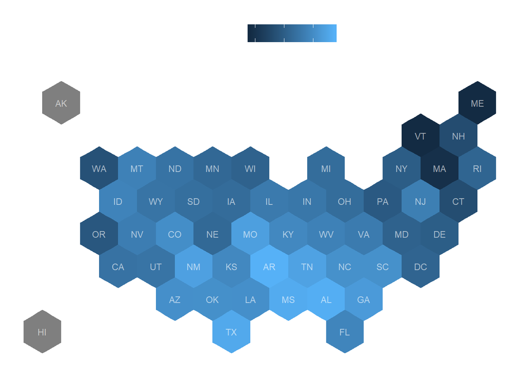

```r
# Make a first chloropleth map
ggplot() +
  geom_polygon(data = spdf_fortified_cat_dogs_percent,
               aes(fill =  percent_diff, x = long, y = lat, group = group)) +
  geom_text(data=centers,
            aes(x=x, y=y, label=id), color="white", size=3, alpha=0.6) +
  theme_void() +
  coord_map() +
  ggtitle( "Dogs Vs Cats, orientation By state" ) +
theme(
    legend.position = "top",
    text = element_text(color = "#ffffff"))
```

```r
# # Prepare binning
# spdf_fortified$bin = cut( spdf_fortified$percent_diff ,
#                           breaks=c(seq(5,10), Inf), labels=c("5-6", "6-7", "7-8", "8-9", "9-10", "10+" ), include.lowest = TRUE )
#
# # Prepare a color scale coming from the viridis color palette
# library(viridis)
# my_palette=rev(magma(8))[c(-1,-8)]
#
# # plot
# ggplot() +
#   geom_polygon(data = spdf_fortified,
#                aes(fill = bin, x = long, y = lat, group = group) , size=0, alpha=0.9) +
#   geom_text(data=centers,
#             aes(x=x, y=y, label=id), color="white", size=3, alpha=0.6) +
#   theme_void() +
#   scale_fill_manual(
#     values=my_palette,
#     name="Wedding per 1000 people in 2015",
#     guide = guide_legend( keyheight = unit(3, units = "mm"), keywidth=unit(12, units = "mm"), label.position = "bottom", title.position = 'top', nrow=1)
#   ) +
#   ggtitle( "A map of marriage rates, state by state" ) +
#   theme(
#     legend.position = c(0.5, 0.9),
#     text = element_text(color = "#22211d"),
#     plot.background = element_rect(fill = "#f5f5f2", color = NA),
#     panel.background = element_rect(fill = "#f5f5f2", color = NA),
#     legend.background = element_rect(fill = "#f5f5f2", color = NA),
#     plot.title = element_text(size= 22, hjust=0.5, color = "#4e4d47", margin = margin(b = -0.1, t = 0.4, l = 2, unit = "cm")),
#   )
#
```

Enough for today !

# future stuff:

- apply to other maps
- playe more with ggplot
- analyze deeper
- make a better report, showing / not showing some stuff & comments.